# har-analysis.Rmd

Shashishekhar S

Wednesday, February 18, 2015

## Objective

To predict the manner in which a group of six data enthusiasts exercised. The enthusiasts took measurements about themselves regularly to improve their health, to find patterns in their behavior. The goal is to use data from accelerometers on the belt, forearm, arm and dumbell of the participants. More information about the activity is available from their website: http://groupware.les.inf.puc-rio.br/har

## Data

The training data and the test data has been made available at the below URLs;

- https://d396qusza40orc.cloudfront.net/predmachlearn/pml-training.csv
- https://d396qusza40orc.cloudfront.net/predmachlearn/pml-testing.csv

However, these files have been stored locally for quicker access.

## Initialize Environment

```r
# import libraries and set the seed to maintain consistency
library(caret)
library(randomForest)
```

```r
library(rpart)
library(rpart.plot)
library(RColorBrewer)
library(rattle)
set.seed(108)
```

## Loading Data

```r
trainUrl <- "data/pml-training.csv"
testUrl <- "data/pml-testing.csv"
```

```r
training <- read.csv(trainUrl, na.strings=c("NA","#DIV/0!",""))
testing <- read.csv(testUrl, na.strings=c("NA","#DIV/0!",""))
```

## Data for training and cross-validation

Partition the training data for “training” and “cross-validation” purposes (‘classe’ is the variable we are interested in)

```r
inTrain <- createDataPartition(y=training$classe, p=0.6, list=FALSE)
datTraining <- training[inTrain, ]; datTesting <- training[-inTrain, ]
dim(datTraining)
```

```
## [1] 11776   160
```

```r
dim(datTesting)
```

```
## [1] 7846  160
```

## Transform, remove and filter to clean up training data

Clean “Near Zero Variance” variables

```r
dataNZV <- nearZeroVar(datTraining, saveMetrics=TRUE)
```

Create subset without the “Near Zero Variance” variables.

```r
datNZVvars <- names(datTraining) %in% c("new_window", "kurtosis_roll_belt", "kurtosis_picth_belt",
  "kurtosis_yaw_belt", "skewness_roll_belt", "skewness_roll_belt.1", "skewness_yaw_belt",
  "max_yaw_belt", "min_yaw_belt", "amplitude_yaw_belt", "avg_roll_arm", "stddev_roll_arm",
  "var_roll_arm", "avg_pitch_arm", "stddev_pitch_arm", "var_pitch_arm", "avg_yaw_arm",
  "stddev_yaw_arm", "var_yaw_arm", "kurtosis_roll_arm", "kurtosis_picth_arm",
  "kurtosis_yaw_arm", "skewness_roll_arm", "skewness_pitch_arm", "skewness_yaw_arm",
  "max_roll_arm", "min_roll_arm", "min_pitch_arm", "amplitude_roll_arm", "amplitude_pitch_arm",
  "kurtosis_roll_dumbbell", "kurtosis_picth_dumbbell", "kurtosis_yaw_dumbbell", "skewness_roll_dumbbell",
  "skewness_pitch_dumbbell", "skewness_yaw_dumbbell", "max_yaw_dumbbell", "min_yaw_dumbbell",
  "amplitude_yaw_dumbbell", "kurtosis_roll_forearm", "kurtosis_picth_forearm", "kurtosis_yaw_forearm",
  "skewness_roll_forearm", "skewness_pitch_forearm", "skewness_yaw_forearm", "max_roll_forearm",
  "max_yaw_forearm", "min_roll_forearm", "min_yaw_forearm", "amplitude_roll_forearm",
  "amplitude_yaw_forearm", "avg_roll_forearm", "stddev_roll_forearm", "var_roll_forearm",
  "avg_pitch_forearm", "stddev_pitch_forearm", "var_pitch_forearm", "avg_yaw_forearm",
  "stddev_yaw_forearm", "var_yaw_forearm")
datTraining <- datTraining[!datNZVvars]
# Updated number of training data
dim(datTraining)
```

```
## [1] 11776   100
```

```r
# Remove first column
datTraining <- datTraining[c(-1)]

# Clean redundant variables/values.  Cleaning Variables with too many NAs.

training_iter <- datTraining
for(i in 1:length(datTraining)) {
        if( sum( is.na( datTraining[, i] ) ) /nrow(datTraining) >= .6 ) {
        for(j in 1:length(training_iter)) {
            if( length( grep(names(datTraining[i]), names(training_iter)[j]) ) == 1)  {
                training_iter <- training_iter[ , -j]
            }
        }
    }
}

# Cleaned data set
dim(training_iter)
```

```
## [1] 11776    58
```

```r
datTraining <- training_iter
rm(training_iter)
```

Now, cleaning up the test data sets

```r
clean1 <- colnames(datTraining)
clean2 <- colnames(datTraining[, -58])
datTesting <- datTesting[clean1]
testing <- testing[clean2]

# Check cleaned data
dim(datTesting)
```

```
## [1] 7846   58
```

```r
dim(testing)
```

```
## [1] 20 57
```

Now, to run through the algorithms, the data in the “test” set must be of the same type.

```r
for (i in 1:length(testing)) {
   for (j in 1:length(datTraining)) {
       if(length(grep(names(datTraining[i]), names(testing)[j])) == 1)  {
           class(testing[j]) <- class(datTraining[i])
     }
  }
}

testing <- rbind(datTraining[2, -58] , testing)
testing <- testing[-1,]
```

## Explore Decision Tree

[figure not shown]

```r
exploreTree <- rpart(classe ~ ., data=datTraining, method="class")
fancyRpartPlot(exploreTree, main="Decision Tree")
```

Use decision tree to predict

```r
predict_dt <- predict(exploreTree, datTesting, type = "class")
```

Test Decision Tree results using Confusion Matrix

```r
confusionMatrix(predict_dt, datTesting$classe)
```

```
## Confusion Matrix and Statistics
##
##           Reference
## Prediction    A    B    C    D    E
##          A 2146   74    8    3    0
##          B   63 1236   91   57    0
##          C   23  200 1246  211    3
##          D    0    8   16  880  105
##          E    0    0    7  135 1334
##
## Overall Statistics
##
##                Accuracy : 0.872
##                  95% CI : (0.864, 0.879)
##     No Information Rate : 0.284
##     P-Value [Acc > NIR] : <2e-16
##
##                   Kappa : 0.838
##  Mcnemar's Test P-Value : NA
##
## Statistics by Class:
##
##                      Class: A Class: B Class: C Class: D Class: E
## Sensitivity             0.961    0.814    0.911    0.684    0.925
## Specificity             0.985    0.967    0.933    0.980    0.978
## Pos Pred Value          0.962    0.854    0.740    0.872    0.904
## Neg Pred Value          0.985    0.956    0.980    0.941    0.983
## Prevalence              0.284    0.193    0.174    0.164    0.184
## Detection Rate          0.274    0.158    0.159    0.112    0.170
## Detection Prevalence    0.284    0.184    0.215    0.129    0.188
## Balanced Accuracy       0.973    0.890    0.922    0.832    0.951
```

## Explore using Random Forest

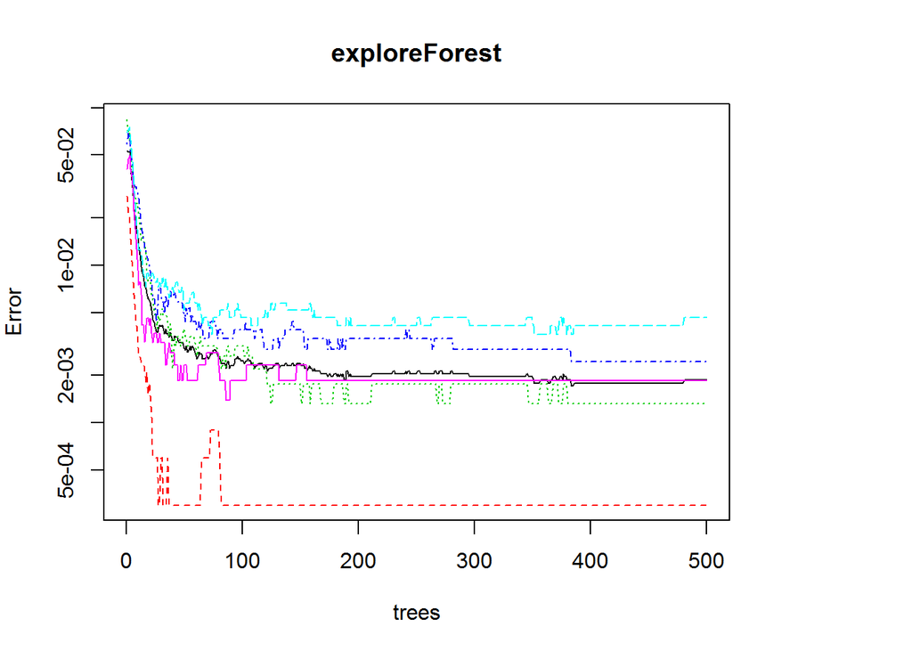

```r
exploreForest <- randomForest(classe ~. , data=datTraining)
layout(matrix(c(1,2),nrow=1),
       width=c(4,1))
par(mar=c(5,4,4,0)) #No margin on the right side
plot(exploreForest, log='y')
par(mar=c(5,0,4,2)) #No margin on the left side
plot(c(0,1),type="n", axes=F, xlab="", ylab="")
```

Use random forest to predict

```r
predict_rf <- predict(exploreForest, datTesting, type = "class")
```

Test Random Forest results using Confusion Matrix

```r
confusionMatrix(predict_rf, datTesting$classe)
```

```
## Confusion Matrix and Statistics
##
##           Reference
## Prediction    A    B    C    D    E
##          A 2232    1    0    0    0
##          B    0 1517    1    0    0
##          C    0    0 1367    1    0
##          D    0    0    0 1285    2
##          E    0    0    0    0 1440
##
## Overall Statistics
##
##                Accuracy : 0.999
##                  95% CI : (0.999, 1)
##     No Information Rate : 0.284
##     P-Value [Acc > NIR] : <2e-16
##
##                   Kappa : 0.999
##  Mcnemar's Test P-Value : NA
##
## Statistics by Class:
##
##                      Class: A Class: B Class: C Class: D Class: E
## Sensitivity             1.000    0.999    0.999    0.999    0.999
## Specificity             1.000    1.000    1.000    1.000    1.000
## Pos Pred Value          1.000    0.999    0.999    0.998    1.000
## Neg Pred Value          1.000    1.000    1.000    1.000    1.000
## Prevalence              0.284    0.193    0.174    0.164    0.184
## Detection Rate          0.284    0.193    0.174    0.164    0.184
## Detection Prevalence    0.285    0.193    0.174    0.164    0.184
## Balanced Accuracy       1.000    1.000    1.000    0.999    0.999
```

Using Random Forest, the results are improved

## Files for answers submission

```r
predict_rf_test <- predict(exploreForest, testing, type = "class")
```

Generate text files as needed for submission

```r
pml_write_files = function(x){
  n = length(x)
  for(i in 1:n){
    filename = paste0("prediction/problem_id_", i, ".txt")
    write.table(x[i], file=filename, quote=FALSE, row.names=FALSE, col.names=FALSE)
  }
}

pml_write_files(predict_rf_test)
```